# Time Series: A First Course with Bootstrap Starter

# Lesson 12-7: Subsampling

- An alternative to the bootstrap is to replicate properties of the sample by examining *subsamples*.

## Paradigm 12.7.1. Roots and Subsampling

- Suppose that $\{ X_t \}$ is strictly stationary.
- We also suppose that the process is $m$-dependent, which says that serial dependence vanishes between variables that are more than lag $m$ apart.
- Suppose $\widehat{\theta}_n$ is an estimator of $\theta$ based on the sample $X_1, \ldots, X_n$.
- Suppose that $\tau_n$ is a rate of convergence for the estimator, such that
  $$\tau_n (\widehat{\theta}_n - \theta) \Rightarrow S,$$
  where $S$ is some random variable with cdf $J$.
- The cdf of our centered statistic is
  $$J_n (x) = {\mathbb P} [ \tau_n (\widehat{\theta}_n - \theta) \leq x ].$$
- So $J_n (x) \rightarrow J(x)$ as $n \rightarrow \infty$.
- We can compute the statistic on smaller sub-spans of the full sample, and the corresponding cdf will also converge.

## Paradigm 12.7.2. Blocking Schemes

- We can divide $X_1, \ldots, X_n$ into smaller blocks.
- Here we focus on overlapping blocks of size $b$, where $b < n$.
- There are $Q = n-b+1$ such blocks, or *subsamples*. For $1 \leq i \leq Q$
  $$X_{i}, \ldots, X_{i+b-1}$$
  is the $i$th subsample.
- Adjacent blocks have $b-1$ values in common.

## Paradigm 12.7.5. Subsampling Methodology

- Consider overlapping blocks, and evaluate the statistic on each:
  $$\widehat{\theta}_{b,i} = \widehat{\theta} ( X_{i}, \ldots, X_{i+b-1}).$$
- The centered statistic is then
  $$Z_{b,i} = \tau_b (\widehat{\theta}_{b,i} - \theta ).$$
  Note the rate is $\tau_b$, not $\tau_n$.
- As $b \rightarrow \infty$, the cdf of $Z_{b,i}$ tends to $J$, for each $i$.
- Fixing $b$, each $Z_{b,i}$ has the same distribution, and they are dependent random variables. The idea is to take their edf to estimate $J_n (x)$.
- However, $\theta$ in $Z_{b,i}$ is unknown, so we replace it by $\widehat{\theta}_n$ based on the whole sample, which converges at a faster rate.
  $$\widehat{Z}_{b,i} = \tau_b (\widehat{\theta}_{b,i} - \widehat{\theta}
  ).$$
- The *classical subsampling estimator* is then defined as
  $$L_{n,b} (x) = \frac{1}{Q} \sum_{i=1}^Q 1_{ \{ \widehat{Z}_{b,i} \leq x
  \} }.$$
- This is an edf. Its quantiles are the order statistics of $\widehat{Z}_{b,i}$.
- Neighboring blocks share lots of time series observations, and the corresponding $\widehat{Z}_{b,i}$ random variables will be more highly correlated.
- By the $m$-dependence assumption, blocks that are sufficiently separated (far apart from one another) will be uncorrelated.
- Assuming that $\tau_b/ \tau_n \rightarrow 0$, the result is a consistent estimator of $J(x)$, and the difference $L_{n,b} (x) - J_n (x)$ tends to zero in probability.

## Example 12.7.13. Subsampling Inference for Lag 1 Autocovariance of Non-Defense Capitalization

- Consider the Non-Defense Capitalization time series.
- After differencing, we wish to estimate $\gamma (1)$ and compute the cdf $\zeta = {\mathbb P} [ \sqrt{n} (\widehat{\gamma} (1) - \gamma (1)) \leq x]$.

```r
ndc <- read.table("Nondefcap.dat")
ndc <- ts(ndc[,2],start=c(1992,3),frequency=12,names= "NewOrders")
ndc.diff <- diff(ndc)
n <- length(ndc.diff)
gamma.hat <- acf(ndc.diff,lag=n-1,type="covariance",plot=FALSE)$acf[,,1]
ndc.acf1 <- gamma.hat[2]
```

- The lag 1 autocovariance is estimated to be -0.002489.
- We use the subsampling methodology, with $\tau_n = \sqrt{n}$.
- First consider $b = 5$.

```r
b.sub <- 5
q.sub <- floor(n-b.sub+1)
sub.edf <- NULL
for(i in 1:q.sub)
{
    sub.ndc <- ndc.diff[i:(i+b.sub-1)]
    gamma.sub <- acf(sub.ndc,lag=b.sub-1,type="covariance",plot=FALSE)$acf[,,1]
    sub.edf <- c(sub.edf,sqrt(b.sub)*(gamma.sub[2]-ndc.acf1))
}
sub.edf <- sort(sub.edf)
interval <- c(sub.edf[floor(.025*q.sub)],sub.edf[floor(.975*q.sub)])
```

- The $95 \%$ confidence interval based on subsampling is [-0.0028679,-0.0015599].
- We plot the subsampling edf.

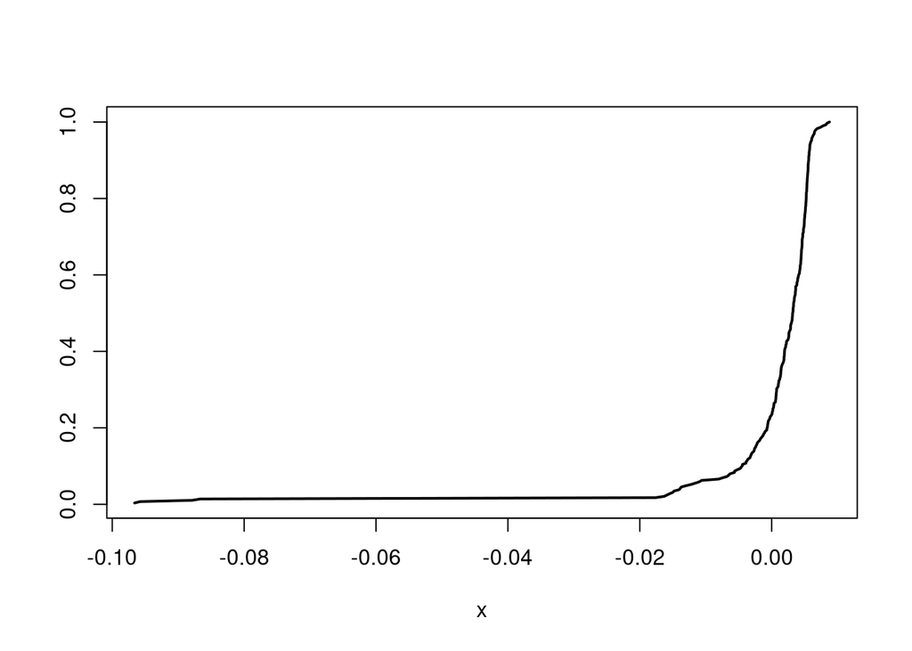

```r
plot(sub.edf,seq(1,q.sub)/q.sub,type="l",xlab="x",ylab="",lwd=2)
```

- Repeat with $b = 10$.

```r
b.sub <- 10
q.sub <- floor(n-b.sub+1)
sub.edf <- NULL
for(i in 1:q.sub)
{
    sub.ndc <- ndc.diff[i:(i+b.sub-1)]
    gamma.sub <- acf(sub.ndc,lag=b.sub-1,type="covariance",plot=FALSE)$acf[,,1]
    sub.edf <- c(sub.edf,sqrt(b.sub)*(gamma.sub[2]-ndc.acf1))
}
sub.edf <- sort(sub.edf)
interval <- c(sub.edf[floor(.025*q.sub)],sub.edf[floor(.975*q.sub)])
```

- The $95 \%$ confidence interval based on subsampling is [-0.0029984,9.7906314^{-4}].
- We plot the subsampling edf.

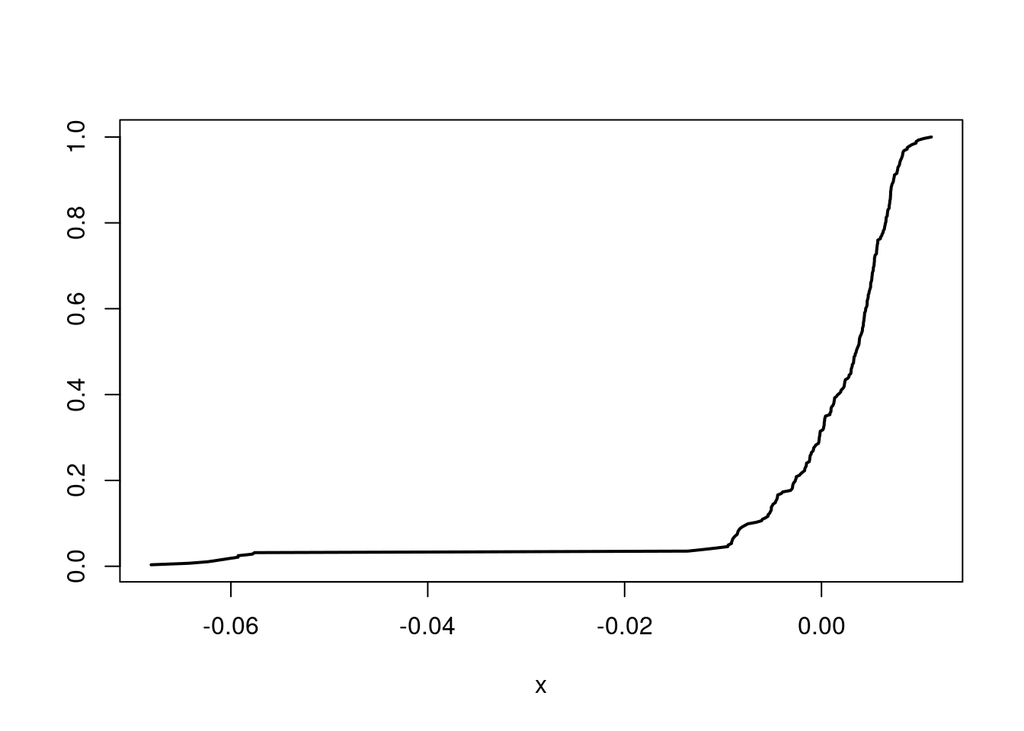

```r
plot(sub.edf,seq(1,q.sub)/q.sub,type="l",xlab="x",ylab="",lwd=2)
```